# Question

Two concentric circles have radii $r_1=1$ meters and $r_2=4.47$ meters. A central angle subtends similar arcs on both circles: a blue arc on the smaller circle and a red arc on the larger circle. The blue arc length is 1.73 meters, as shown in the diagram below.

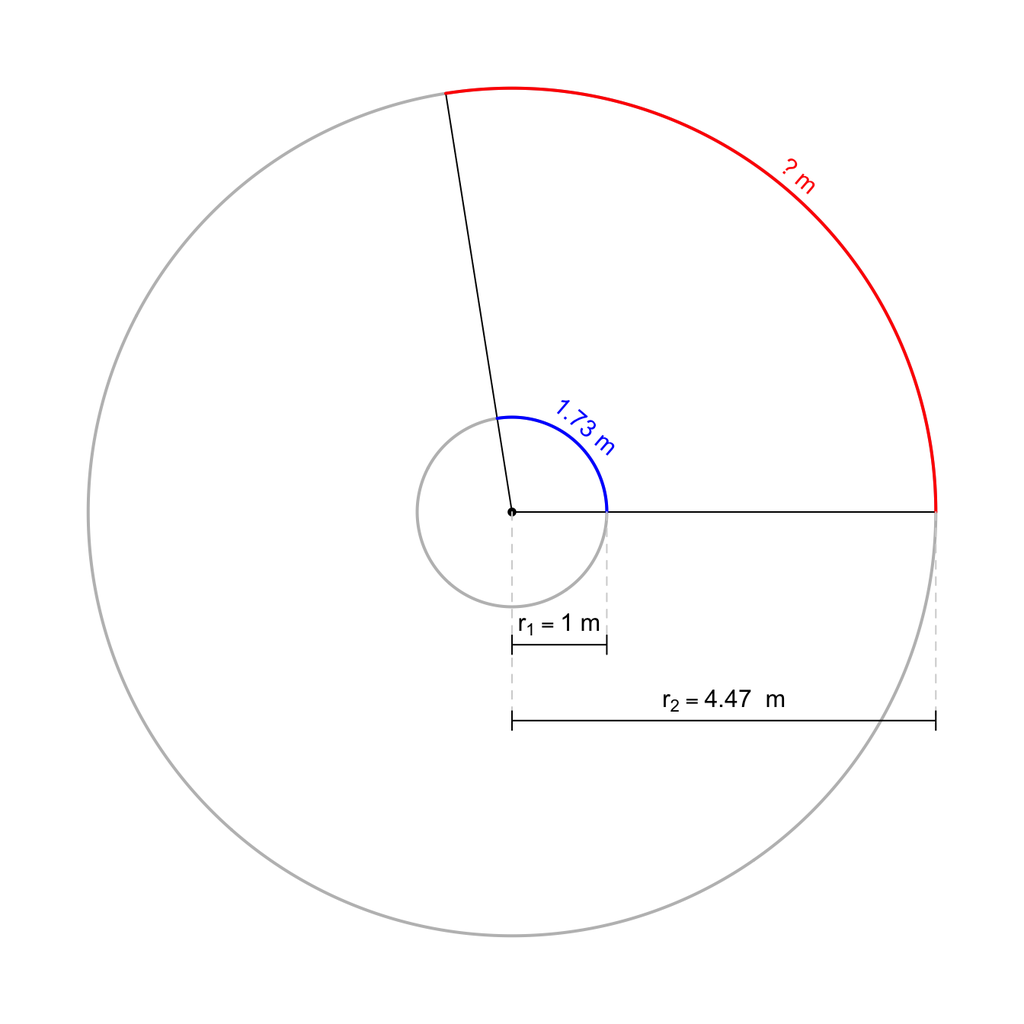

What is the length, in meters, of the red arc? *The tolerance is set to $\pm0.01$ meters.*

# Solution

Okay, this might seem absurdly easy if you are comfortable with similarity.

$$\frac{1}{1.73} ~=~
\frac{4.47}{?}$$

$$?~=~ 1.73\cdot 4.47 ~=~
7.7331$$

I am trying to introduce the **[radian](https://en.wikipedia.org/wiki/Radian)**, which is the arc length of a unit circle.

- Massachusetts learning objective F-TF.A.1:
  - Understand radian measure of an angle as the length of the arc on the unit circle subtended by the angle.

In this case, the central angle is 99°, which is approximately equivalent to 1.73 radians. To convert between degrees and radians, we can multiply by $\frac{\pi}{180^{\circ}}$ to go from degrees to radians or multiply by $\frac{180^{\circ}}{\pi}$ to convert from radians to degrees.

As you progress in math, you’ll use **radians** by default, not degrees. One of the best reasons for this depends on concepts learned in calculus… but in short… if we use radians, then the [derivative](https://en.wikipedia.org/wiki/Derivative) of $\sin(x)$ is simply $\cos(x)$. If we used degrees, then calculus with trigonometric functions would be more annoying.

If you look up [circular arc](https://en.wikipedia.org/wiki/Circular_arc#Length) on wikipedia, you’ll see a formula relating the arc length ($L$) to radius ($r$) and the central angle **measured in radians** ($\theta$).
$$L~=~r\theta$$

So, in our case:

$$L~=~(4.47)(1.73)$$

$$L~=~7.7331~\text{m}$$

# Meta-information

extype: num exsolution: 7.7331 exname: arc_length_from_unit_arc extol: 0.01